# iSystems_01_Networks

**Networks**

- Structural Analysis and Visualization of Networks
  - by Prof. Leonid Zhukov
  - http://www.leonidzhukov.net/hse/2015/networks/
  - Slides
  - Videos
  - ipython notebook
- Data Mining
  - by Prof. Jeff Phillips
  - http://www.cs.utah.edu/~jeffp/teaching/cs5140.html
  - http://www.cs.utah.edu/~jeffp/teaching/cs5140-S15/cs5140.html
  - https://www.youtube.com/channel/UCcrlwW88yMcXujhGjSP2WBg

|  | by Seungchul Lee iSystems Design Lab http://isystems.unist.ac.kr/ UNIST |
| --- | --- |

Table of Contents

# 1. Degree

**Undirected graph**

- The degree of vertex in a graph is the number of edges connected to it
- denote the degree of vertex $i$ by $k_{i}$
- for an undirected graph of $n$ vetices

$$ k_i = \sum_{j=1}^{n} \; A_{ij} $$

- Every edge in an undirected graph has two ends and if there are $m$ edges

$$ 2m = \sum_{i=1}^{n} \; k_i $$

- the mean degree $c$ of a vertex

$$ c = \frac{1}{n} \sum_{i=1}^{n} \; k_i $$

- the maximum possible number of edges in a graph is $\left( \begin{array}{c} n\\2 \end{array} \right) = \frac{n(n-1)}{2}$
- *density* $\rho$ of a graph is the fraction of these edges that are actually present

$$ \rho = \frac{m}{\left( \begin{array}{c} n\\2 \end{array} \right)}$$

**Directed graph**

- in-degree: the number of incoming edges connected to a vertex

$$ k_i^{\text{in}} = \sum_{j=1}^{n} \; A_{ij} $$

- out-degree: the number of outgoing edges

$$ k_i^{\text{out}} = \sum_{i=1}^{n} \; A_{ij} $$

# 2. Centrality

- Which are the most *important* or central vertices in a network?
- *degree centrality* is a simple centrality measure
  - in a social network, it seems reasonable to suppose that inidividuals who have connections to many others might have more influence, more access to information

## 2.1. Eigenvector centrality

- not all neighbors are equivalent
- increase importance by having connections to other vertices that are *themselves important*
- sum of the centrality (ranks, scores) of its in-comming neighbors
- iteratively update

$$ \begin{align*} r_i \leftarrow \sum_{j \, \in \, N(i)} r_j = \sum_{j} A_{ji}r_j \end{align*} $$

- matrix form with a *row* vector of $r$

$$ \begin{align*} &1) \quad r \leftarrow r\,A &\text{update}\\ &2) \quad r \leftarrow \frac{r}{\parallel r \parallel_1}& \text{normalize} \end{align*} $$

- left eigenvector of the adjacency matrix A associated with the largest eigenvalue

$$ \lambda \, r = r\,A $$

- [online note](http://www.sci.unich.it/~francesc/teaching/network/eigenvector.html)

## 2.2. Google PageRank

- Source
  - Networks: Friends, Money, and Bytes
  - by Prof. Mung Chiang at Princeton University
  - [youtube](https://www.youtube.com/user/Network20Q/playlists) playlist
- Consider World Wide Web as a graph (or network)
- Question: which page is more important?
- For Google, which page among google search results should be placed on top?

[figure not shown]

- Read [Wikipedia](https://en.wikipedia.org/wiki/PageRank)
- The [original PageRank paper](http://infolab.stanford.edu/~backrub/google.html) by Google’s founders Sergey Brin and Lawrence Page

|  | $$ A = \begin{bmatrix} 0 & 0 & 1 & 0\\ 0 & 0 & 1 & 0\\ 0 & 0 & 0 & 1\\ 1 & 1 & 1 & 0 \end{bmatrix}$$ |
| --- | --- |

- In-degree
  - What makes a page important?
  - Possible measure
    - In-degree: measure of the number of incoming links a node has ($1,1,3,1$)
  - Does this tell the whole story?
- Importance score, $\pi_i$ for node $i$ $$ \pi = \left[\pi_1,\, \pi_2,\, \pi_3,\, \pi_4 \right]$$
  - each node...
    - has its own importance score
    - Spreads an equal amount of its importance to each outgoing link
  - *row vector by convention*
  - Out-degree: the number of outgoing links from a node $\to (1,1,1,3)$
  - *Markov chain* with transition probability matrix $H$

$$ H = D^{-1}A = \begin{bmatrix} 1 & 0 & 0 & 0\\ 0 & 1 & 0 & 0\\ 0 & 0 & 1 & 0\\ 0 & 0 & 0 & \frac{1}{3} \end{bmatrix} \begin{bmatrix} 0 & 0 & 1 & 0\\ 0 & 0 & 1 & 0\\ 0 & 0 & 0 & 1\\ 1 & 1 & 1 & 0 \end{bmatrix} = \begin{bmatrix} 0 & 0 & \frac{1}{1} & 0\\ 0 & 0 & \frac{1}{1} & 0\\ 0 & 0 & 0 & \frac{1}{1}\\ \frac{1}{3} & \frac{1}{3} & \frac{1}{3} & 0 \end{bmatrix}$$

- Simultaneous equations
  - We can write each node's score in terms of its incoming links
  - Recursion: seemingly circular logic

    $$ \begin{align*} \pi_1 &= \frac{\pi_4}{3}\\ \pi_2 &= \frac{\pi_4}{3}\\ \pi_3 &= \pi_1 + \pi_2 + \frac{\pi_4}{3}\\ \pi_4 &= \pi_3 \end{align*} $$

    $$ H = \begin{bmatrix} 0 & 0 & \frac{1}{1} & 0\\ 0 & 0 & \frac{1}{1} & 0\\ 0 & 0 & 0 & \frac{1}{1}\\ \frac{1}{3} & \frac{1}{3} & \frac{1}{3} & 0 \end{bmatrix}$$
  - or eigenvalue problem (transposed) $$ \left[\pi_1,\, \pi_2,\, \pi_3,\, \pi_4 \right] \times \begin{bmatrix} 0 & 0 & \frac{1}{1} & 0\\ 0 & 0 & \frac{1}{1} & 0\\ 0 & 0 & 0 & \frac{1}{1}\\ \frac{1}{3} & \frac{1}{3} & \frac{1}{3} & 0 \end{bmatrix} = 1\left[\pi_1,\, \pi_2,\, \pi_3,\, \pi_4 \right] $$

```matlab
A = [0 0 1 0;
     0 0 1 0;
     0 0 0 1;
     1 1 1 0];

d = [1 1 1 3];

H = inv(diag(d))*A;

[V,D] = eig(H');
diag(D)
V(:,1)'/sum(V(:,1),1)
```

```
ans =

   1.0000 + 0.0000i
  -0.5000 + 0.6455i
  -0.5000 - 0.6455i
   0.0000 + 0.0000i


ans =

    0.1250    0.1250    0.3750    0.3750
```

```matlab
% iterative

N = 4;
r = 1/N*ones(1,N); % random guess
pre_r = inf*ones(size(r));

while norm(pre_r - r,1) > eps
    pre_r = r;
    r = r*H;
end

r
```

```
r =

    0.1250    0.1250    0.3750    0.3750
```

- Dangling nodes
  - Does what we just presented always lead to a unique solution?
  - Not quite yet !

[figure not shown]

  - Dangling nodes
    - nodes that do not point to any others
    - lead to no meaningful solution
    - Solution: assume dangling node points to every node in the graph ($\rightarrow$ random surfer)
- The Random Surfer
  - Surfing the web at random
  - Two possible actions
    - pick a hyperlink randomly from the current page
    - enter a URL randomly
  - Stochastic matrix $H'$

$$H' = H + \frac{1}{N}d \mathbf{1}^T \qquad$$

$\qquad \qquad $where $d$ is dangling (absorbing) nodes indicator column vector and $\mathbb{1}$ is a unit column vector

$$ H' = \begin{bmatrix} 0 & 0 & 0 & 1\\ \frac{1}{3} & 0 & \frac{1}{3} & \frac{1}{3}\\ \frac{1}{3} & \frac{1}{3} & 0 & \frac{1}{3}\\ 0 & 0 & 0 & 0 \end{bmatrix} + \begin{bmatrix} 0 & 0 & 0 & 0\\ 0 & 0 & 0 & 0\\ 0 & 0 & 0 & 0\\ \frac{1}{4} & \frac{1}{4} & \frac{1}{4} & \frac{1}{4} \end{bmatrix} = H + \frac{1}{4} \begin{bmatrix} 0\\0\\0\\1\end{bmatrix} \begin{bmatrix} 1 & 1 & 1 &1 \end{bmatrix} $$

```matlab
A = [0 0 0 1;
     1 0 1 1;
     1 1 0 1;
     0 0 0 0];

s = sum(A,2);

H2 = zeros(size(A));

for i = 1:N
    if s(i) ~=0
        H2(i,:) = A(i,:)/s(i);
    else
        H2(i,:) = 1/N*ones(N,1);
    end
end

H2
```

```
H2 =

         0         0         0    1.0000
    0.3333         0    0.3333    0.3333
    0.3333    0.3333         0    0.3333
    0.2500    0.2500    0.2500    0.2500
```

```matlab
% iterative

r = 1/N*ones(1,N);
pre_r = inf*ones(size(r));

while norm(pre_r - r,1) > eps
    pre_r = r;
    r = r*H2;
end

r
```

```
r =

    0.2222    0.1667    0.1667    0.4444
```

- Disconnected graph
  - Connected component - group of nodes which can reach eath other, but none outside of the group
  - More than one connected component
    - Infinitely many solutions
    - Stuck in subgraph forever
    - Solution: add the purely random surfing into the mix
      - you get bored, enter a URL randomly
  - PageRank: what is the chance a page is selected at any time?
  - Google matrix $G$

$$G = \alpha H' + (1-\alpha)\frac{1}{N}\mathbf{1}\mathbf{1}^T$$

```matlab
A = [1 1 0 0;
     1 1 0 0;
     0 0 1 1;
     0 0 1 1];

s = sum(A,2);

H2 = zeros(size(A));

for i = 1:length(s)
    if s(i) ~=0
        H2(i,:) = A(i,:)/s(i);
    else
        H2(i,:) = 1/N*ones(N,1);
    end
end

H2
alpha = 0.85;
G = alpha*H2 + (1-alpha)*1/N*ones(N,N)
```

```
H2 =

    0.5000    0.5000         0         0
    0.5000    0.5000         0         0
         0         0    0.5000    0.5000
         0         0    0.5000    0.5000


G =

    0.4625    0.4625    0.0375    0.0375
    0.4625    0.4625    0.0375    0.0375
    0.0375    0.0375    0.4625    0.4625
    0.0375    0.0375    0.4625    0.4625
```

```matlab
% iterative

r = 1/N*ones(1,N);
pre_r = inf*ones(size(r));

while norm(pre_r - r,1) > eps
    pre_r = r;
    r = r*G;
end

r
```

```
r =

    0.2500    0.2500    0.2500    0.2500
```

### 2.2.1. PageRank Computations

1. Eigenvalue problem (choose left eigenvector $\pi$ with $\lambda = 1$)

   $$ \pi G = 1 \pi \implies \pi = \alpha \pi H' + (1-\alpha)\frac{1}{N}\mathbf{1}^T$$

   where $\pi$ is stationary distribution of Markov chain, and raw vector by convention
2. Power iterations:

$$ \pi \leftarrow \pi \left(\alpha H' + (1-\alpha)\frac{1}{N}\mathbf{1}\mathbf{1}^T \right) = \alpha \pi H' + (1-\alpha)\frac{1}{N}\mathbf{1}^T $$

### 2.2.2. Summary

|  | $H $ | from webgraph |
| --- | --- | --- |
|  | $H' = H + \frac{1}{N}d \mathbf{1}^T \qquad$ | to overcome dangling issue |
|  | $G = \alpha H' + (1-\alpha)\frac{1}{N}\mathbf{1}\mathbf{1}^T= \alpha \left( H + \frac{1}{N}d \mathbf{1}^T\right) + (1-\alpha)\frac{1}{N}\mathbf{1}\mathbf{1}^T$ | to overcome disconnected subgraph |

$$ \pi [k+1] = \pi [k] G$$

# 3. Graph Partitioning Algorithms

- **Network communities** are groups of vertices similar to each other
  - similarity-based clustering ($\to$ inner product)
  - example: you are defined by your connections (friends)
- **Network communities** are groups of vertices such vertices inside the group connected with many more edges than between groups
  - graph partitioning (or community detection)

## 3.1. Graph partitioning

- the spectral partitioning
- bisection problem (dividing a graph into two parts of specified sizes)

Graph $G(E,V)$ partition: $V=V_1 + V_2$

- graph cut $$ Q=\text{cut}\left(V_1,V_2 \right) = \sum_{i\in V_1,\; j\in V_2}{e_{ij}} $$
- ratio cut $$ Q=\frac{\text{cut}\left(V_1,V_2 \right)}{\parallel V_1 \parallel} + \frac{\text{cut}\left(V_1,V_2 \right)}{\parallel V_2 \parallel}$$

```matlab
%%html
<center><iframe src="https://www.youtube.com/embed/fPaOkWzJySQ"
width="560" height="315" frameborder="0" allowfullscreen></iframe></center>
```

[video not shown]

```matlab
%%html
<center><iframe src="https://www.youtube.com/embed/BgCukCFZr9A"
width="560" height="315" frameborder="0" allowfullscreen></iframe></center>
```

[video not shown]

## 3.2. Spectral partitioning

### 3.2.1. Graph Laplacian and Optimization

- indicator vector

$$ s_i = \begin{cases} +1 & \quad \text{if } u_i \in V_1\\ -1 & \quad \text{if } u_i \in V_2 \end{cases}$$

- number of edges, connecting $V_1$ and $V_2$

$$ \begin{align*} \text{cut}\left(V_1,V_2 \right) &= \frac{1}{4} \sum_{e(i,\,j)}(s_i - s_j)^2 = \frac{1}{8} \sum_{i,\,j} A_{ij}(s_i - s_j)^2 \\&= \frac{1}{8} \sum_{i,\,j} A_{ij}(s_i^2 - 2 s_i s_j + s_j^2) = \frac{1}{4} \sum_{i,\,j} A_{ij}(s_i^2 - s_i s_j) \\ & = \frac{1}{4} \sum_{i} \sum_{j} A_{ij} s_i^2 - \frac{1}{4} \sum_{i,\,j}A_{ij}s_i s_j = \frac{1}{4} \sum_{i} \left(\sum_{j} A_{ij}\right) s_i^2 - \frac{1}{4} \sum_{i,\,j}A_{ij}s_i s_j \\&= \frac{1}{4} \sum_{i} k_i s_i^2 - \frac{1}{4} \sum_{i,\,j}A_{ij}s_i s_j\\ & = \frac{1}{4} \sum_{i,\,j} \left(k_i \delta_{ij}s_i^2 - A_{ij}s_i s_j\right) = \frac{1}{4} \sum_{i,\,j} \left( k_i \delta_{ij} - A_{ij}\right)s_i s_j = \frac{1}{4} \sum_{i,\,j} \left( D_{ij} - A_{ij}\right)s_i s_j \end{align*} $$

- Graph Laplacian: $L_{ij} = D_{ij} - A_{ij}$, where $D_{ij} = \text{diag}(k_i)$

$$ L_{ij} = \begin{cases} \;\; k_i &\quad \text{if } i = j\\ -1 &\quad \text{if } \exists \; e(i,j)\\ \;\; 0 &\quad \text{otherwise}\end{cases}$$

- matrix form

$$Q(s) = \frac{1}{4} s^T L s$$

- optimization $$ \begin{align*} \min_s \quad & Q(s) \\ \text{subject to } & \sum_i s_i = 0 \qquad (\Rightarrow \text{balanced cut constraint})\\ & s_i \in \{+1,-1\} \end{align*} $$
- integer minimizaiton problem, but exact solution is NP-hard

### 3.2.2. Relaxed spectral method

- $\text{discrete } s_i \rightarrow \text{continuous } x_i$

[output not shown]

| $$ \frac{x}{\sqrt{n}} \rightarrow x$$ | $\implies$ | $$ \begin{align*} \min_x \quad & \; x^T L x\\ \text{subject to } & x^T \mathbb{1} = 0\\ & x^Tx = 1 \end{align*} $$ | $\implies$ | $$ \begin{align*} \min_x \quad & \; \frac{x^T L x}{x^Tx}\\ \text{subject to } & x^T \mathbb{1} = 0\\ \end{align*} $$ |
| --- | --- | --- | --- | --- |

- given $x_i$, round them up by $s_i = \text{sign}(x_i)$

**Solution**

- Eigenvalue problem $$ Lx = \lambda x, \quad x \perp \mathbb{1} $$
  $$ \begin{align*} \min_x \quad & \; \frac{x^T L x}{x^Tx} = \min_x \; \lambda\\ \\ \text{subject to } & x^T \mathbb{1} = 0\\ \end{align*} $$
- First (smallest) eigenvector $=\mathbb{1}$ $$ L\mathbb{1} = 0 = 0\mathbb{1} \; \implies \; \lambda = 0, \quad x_1 = \mathbb{1} $$
- Looking for the second smallest eigenvalue/eigenvector $\lambda_2$ and $x_2$

$$ x_2 \perp x_1 = \mathbb{1}$$

**Solution using Lagrange multipliers (optional)**

$$ Q(x) = \frac{1}{4} x^T L x - \lambda (x^Tx-n), \quad x^T \mathbb{1} = 0 $$

- Eigenvalue problem $$ Lx = \lambda x, \quad x \perp \mathbb{1} $$
- Solution $$ Q(x) = \frac{n}{4} \lambda $$
- First (smallest) eigenvector $=\mathbb{1}$ $$ L\mathbb{1} = 0, \quad \lambda = 0, \quad x_1 = \mathbb{1} $$
- Looking for the second smallest eigenvalue/eigenvector $\lambda_2$ and $x_2$

$$ x_2 \perp x_1 = \mathbb{1}$$

## 3.3. Example 1

```matlab
A = [0 0 0 1 1 0 1 0;
     0 0 0 1 0 1 0 1;
     0 0 0 0 1 0 1 0;
     1 1 0 0 0 1 0 0;
     1 0 1 0 0 0 1 0;
     0 1 0 1 0 0 0 1;
     1 0 1 0 1 0 0 0;
     0 1 0 0 0 1 0 0];

L = diag(sum(A,1)) - A;
[V,D] = eig(L);
diag(D)
[ds,Y] = sort(diag(D));
u2 = V(:,Y(2))
[v2,I] = sort(u2,'ascend');
```

```
ans =

   -0.0000
    0.2907
    2.0000
    2.8061
    4.0000
    4.0000
    4.0000
    4.9032


u2 =

   -0.1993
    0.3696
   -0.4325
    0.1993
   -0.3696
    0.3696
   -0.3696
    0.4325
```

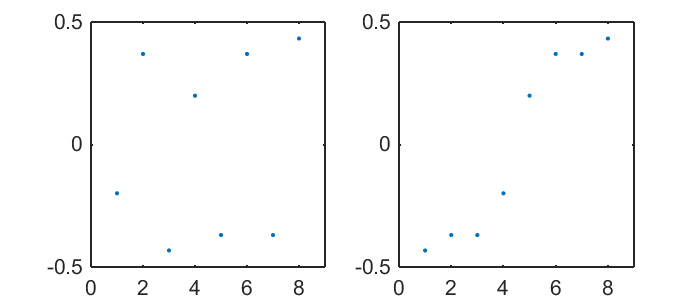

```matlab
%plot -s 700,300
subplot(1,2,1), plot(1:8,u2,'.'), xlim([0 9])
subplot(1,2,2), plot(1:8,v2,'.'), xlim([0 9])
```

```matlab
A
B = A(I,I)

I
```

```
A =

     0     0     0     1     1     0     1     0
     0     0     0     1     0     1     0     1
     0     0     0     0     1     0     1     0
     1     1     0     0     0     1     0     0
     1     0     1     0     0     0     1     0
     0     1     0     1     0     0     0     1
     1     0     1     0     1     0     0     0
     0     1     0     0     0     1     0     0


B =

     0     1     1     0     0     0     0     0
     1     0     1     1     0     0     0     0
     1     1     0     1     0     0     0     0
     0     1     1     0     1     0     0     0
     0     0     0     1     0     1     1     0
     0     0     0     0     1     0     1     1
     0     0     0     0     1     1     0     1
     0     0     0     0     0     1     1     0


I =

     3
     5
     7
     1
     4
     6
     2
     8
```

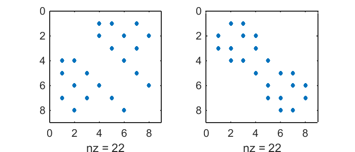

```matlab
%plot -s 700,300
subplot(1,2,1), spy(A)
subplot(1,2,2), spy(B)
```

## 3.4. Example 2

[figure not shown]

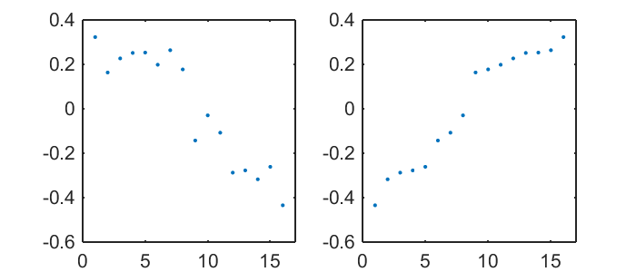

```matlab
%plot -s 700,300
A = [0 0 0 0 1 0 1 0 0 0 0 0 0 0 0 0;
     0 0 1 1 1 0 0 0 1 0 0 0 0 0 0 0;
     0 1 0 1 1 1 0 1 0 0 0 0 0 0 0 0;
     0 1 1 0 0 0 1 0 0 0 0 0 0 0 0 0;
     1 1 1 0 0 1 0 0 0 0 0 0 0 0 0 0;
     0 0 1 0 1 0 1 0 0 1 0 0 0 0 0 0;
     1 0 0 1 0 1 0 1 0 0 0 0 0 0 0 0;
     0 0 1 0 0 0 1 0 0 1 0 0 0 0 0 0;
     0 1 0 0 0 0 0 0 0 1 1 1 1 0 1 0;
     0 0 0 0 0 1 0 1 1 0 1 0 0 0 1 0;
     0 0 0 0 0 0 0 0 1 1 0 0 0 0 0 0;
     0 0 0 0 0 0 0 0 1 0 0 0 0 1 0 0;
     0 0 0 0 0 0 0 0 1 0 0 0 0 1 1 0;
     0 0 0 0 0 0 0 0 0 0 0 1 1 0 1 0;
     0 0 0 0 0 0 0 0 1 1 0 0 1 1 0 1;
     0 0 0 0 0 0 0 0 0 0 0 0 0 0 1 0;
    ];

L = diag(sum(A,1)) - A;
[V,D] = eig(L);

u2 = V(:,2);
[v2,I] = sort(u2,'ascend');

subplot(1,2,1), plot(1:16,u2,'.'), xlim([0 17])
subplot(1,2,2), plot(1:16,v2,'.'), xlim([0 17])
```

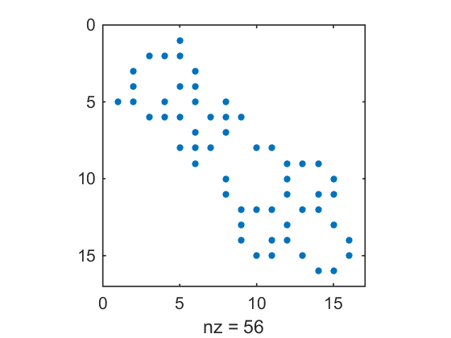

```
ans =

     9    10    11    12    13    14    15    16
```

```matlab
spy(A(I,I))

S = 1:16;
S(u2<0)
```

[figure not shown]

## 3.5. Example 3: Zachary Karate Club

- Zachary's Karate Club is a well-known social network of a university karate club described in "An Information Flow Model for Conflict and Fission in Small Groups" paper by Wayne W. Zachary.
- A social network of a karate club was studied by Wayne W. Zachary for a period of three years from 1970 to 1972. The network captures 34 members of a karate club, documenting 78 pairwise links between members who interacted outside the club. During the study a conflict arose between the administrator "John A" and instructor "Mr. Hi" (pseudonyms), which led to the split of the club into two. Half of the members formed a new club around Mr. Hi, members from the other part found a new instructor or gave up karate. Basing on collected data Zachary assigned correctly all but one member of the club to the groups they actually joined after the split.
- Source:
  - https://en.wikipedia.org/wiki/Zachary%27s_karate_club
  - http://konect.uni-koblenz.de/networks/ucidata-zachary
  - http://www-personal.umich.edu/~mejn/netdata/

[figure not shown]

- note: node labels start from 0

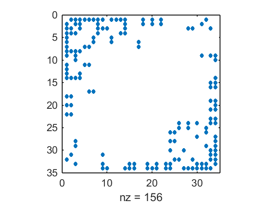

```matlab
%plot -s 560,420
[A,~] = xlsread([pwd,'\image_files\matrix_noheader.csv']);
spy(A)
```

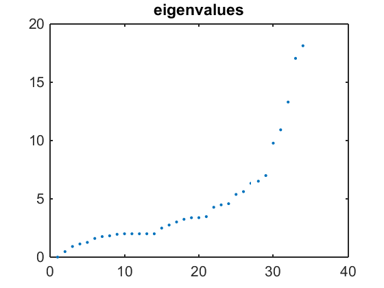

```matlab
L = diag(sum(A,1)) - A;
[V,D] = eig(L);
plot(1:34,diag(D),'.'), title('eigenvalues')
```

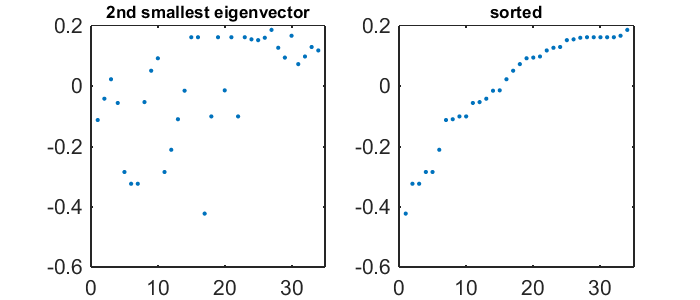

```matlab
%plot -s 700,300
u2 = V(:,2);
[v2,I] = sort(u2,'ascend');

subplot(1,2,1), plot(1:34,u2,'.'), title('2nd smallest eigenvector','fontsize',8), xlim([0 35])
subplot(1,2,2), plot(1:34,v2,'.'), title('sorted','fontsize',8), xlim([0 35])
```

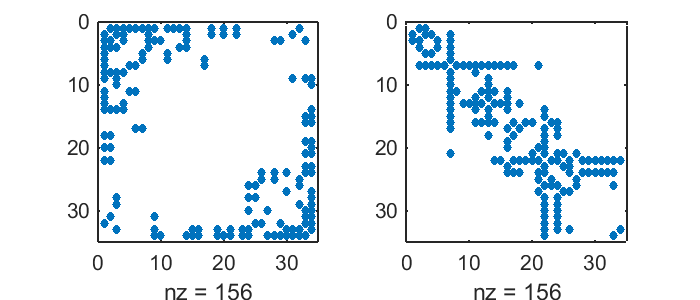

```
ans =

     1     2     4     5     6     7     8    11    12    13    14    17    18    20    22
```

```matlab
%plot -s 700,300
subplot(1,2,1), spy(A)
subplot(1,2,2), spy(A(I,I))

S = 1:34;
S(u2<0)
```

- Node 1 stands for the instructor, node 34 for the president

## 3.6. Normalized cut (optional)

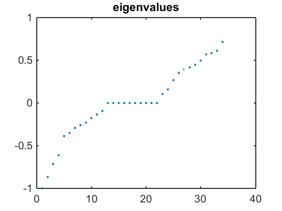

```matlab
%plot -s 560,420
n = length(A);
deg = sum(A); % for other than simple graphs, use [deg,~,~]=degrees(adj);

L = zeros(n);
edges = find(A>0);

for e = 1:length(edges)
    [i,j] = ind2sub([n,n],edges(e));
    if i == j
        L(i,i) = 1;
        continue
    end
    L(i,j) = -1/sqrt(deg(i)*deg(j));
end

%%
[V,D] = eig(L);
plot(1:34,diag(D),'.'), title('eigenvalues')
```

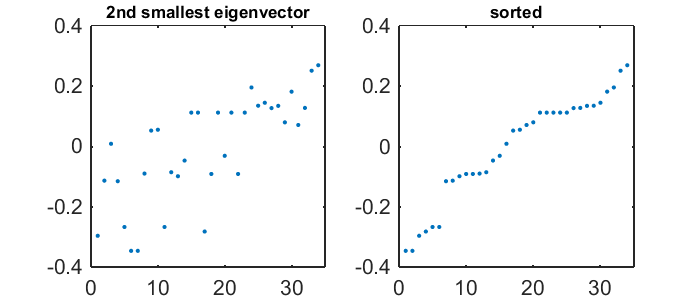

```matlab
%plot -s 700,300
u2 = V(:,2);
[v2, I] = sort(u2,'ascend');

subplot(1,2,1), plot(1:34,u2,'.'), title('2nd smallest eigenvector','fontsize',8), xlim([0 35])
subplot(1,2,2), plot(1:34,v2,'.'), title('sorted','fontsize',8), xlim([0 35])
```

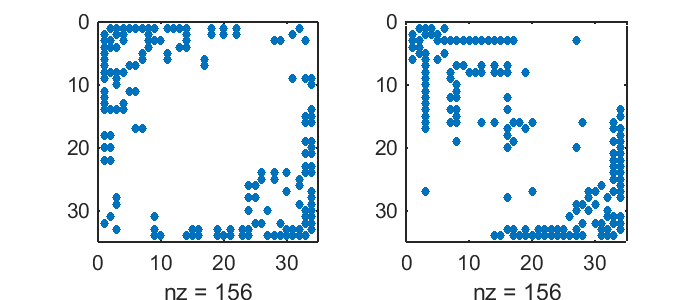

```
ans =

     1     2     4     5     6     7     8    11    12    13    14    17    18    20    22
```

```matlab
%plot -s 700,300
subplot(1,2,1), spy(A)
subplot(1,2,2), spy(A(I,I))

S = 1:34;
S(u2<0)
```

- Node 1 stands for the instructor, node 34 for the president

[figure not shown]

```matlab
imagesc(A(I,I)), colormap('hot'), axis equal, axis off
```

## 3.7. Flocking Example

```matlab
%%html
<center><iframe src="https://www.youtube.com/embed/t3Gp4vob_t8"
width="560" height="315" frameborder="0" allowfullscreen></iframe></center>
```

[video not shown]

[figure not shown]

```matlab
%%javascript
$.getScript('https://kmahelona.github.io/ipython_notebook_goodies/ipython_notebook_toc.js')
```